# HW2

Brent Scott

9/27/2021

```r
#parameters
body_mass_kg <- 70
bike_mass_kg <- 10
treadmill_incline_degrees <- 4.12
```

1a) What is the component of the gravitational force perpendicular to the treadmill?

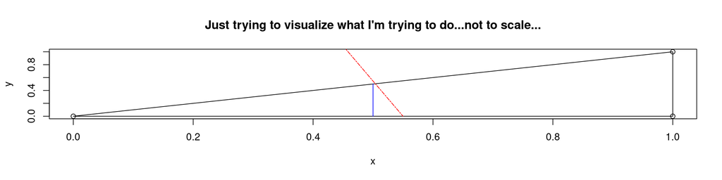

```r
# convert degrees to radians
# 1 degree =  pi/180 = 0.01745 radians...
angle_radians <- treadmill_incline_degrees*(pi/180)
x <- c(1, 1, 0)
y <- c(1, 0, 0)
plot(x, y, main = "Just trying to visualize what I'm trying to do...not to scale...")
polygon(x, y)
lines(c(0, 0.55), c(6, 0), col = "red", lty = 12)
lines(c(0.5, 0.5), c(0.5, 0), col = "blue")
```

```r
# the internet told me  f_perp = m * g * cos(angle)

cos_angle <- cos(angle_radians)
f_g_bike <- 9.81 * bike_mass_kg
f_perp_bike <- f_g_bike * cos_angle
```

The gravitational force perpendicular to the treadmill for just the bike is **97.85 N**

1b) What is the component of the gravitational force parallel to the treadmill?

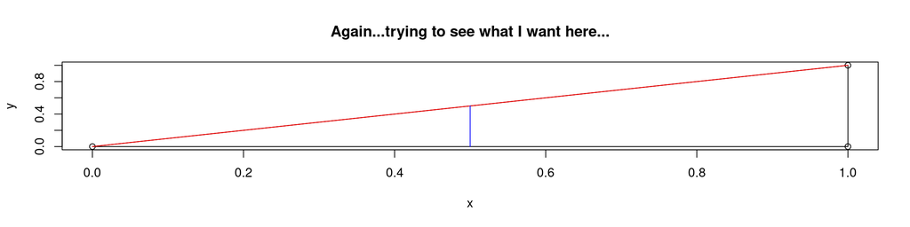

```r
plot(x, y, main = "Again...trying to see what I want here...")
polygon(x, y)
lines(c(0, 1), c(0, 1), col = "red")
lines(c(0.5, 0.5), c(0.5, 0), col = "blue")
```

```r
# the internet told me f_para  = m * g * sin(angle)
f_para_bike <- f_g_bike * sin(angle_radians)
```

1c&d) When coasting on the treadmill, the bike stays stationary for a hanging mass of 6.07 kg. How much is the rolling resistance force?

```r
# Crr  = Fhang / Fn, where Fhang = Fhang - Fg_paralell
f_hang <- 6.07 * 9.81
crr <- (f_hang - f_para_bike )/ (9.81*body_mass_kg)
```

The coefficient of rolling resistance is 0.08 N…maybe…

What is the difference between rolling resistance force and power?

```r
# rolling resistance power is equal to (M+m)*g * cos(angle) * Crr * velocity
# is force no velocity componenet?
roll_res_force <- (bike_mass_kg)*9.81 * cos(angle_radians) * crr
```

The rolling resistance power calculation without a velocity is 7.48 N…

Now riding at 4m/s…

```r
# mechanical power  = vertical power + rolling resistance power * 1.02
v <- 4
vert_power <- (body_mass_kg+bike_mass_kg) * 9.81 * v * sin(angle_radians)
roll_res_power <- (body_mass_kg+bike_mass_kg) * 9.81 * cos(angle_radians) * crr * v
total_power <- (vert_power + roll_res_power) * 1.02
```

2a) To overcome gravity alone…his vertical power would need to be 225.54 Watts.

2b) He is on a treadmill and not moving so there is no air resistance.

2c) Mechanical power to overcome just rolling resistance would be 239.4 Watts.

2d) With a 2% drive train loss total power needed is 474 Watts.

2e) I don’t know what a 4iiii power meter is so I would not buy one. They should probably advertise better 😉.

2f) Hopefully he is a better cyclist than I am a biomechanist…